# Regressão linear StackOverflow e SuperUser

```r
library(openintro)
library(tidyverse)
library(tidymodels)
theme_set(theme_bw())

knitr::opts_chunk$set(tidy = FALSE,
                      fig.width = 6,
                      fig.height = 5)
```

*Dados utilizados:* *OBS: Os dados de GNI e EPI de alguns países não estão disponíveis*

```r
paises = read_csv(here::here("data/participation-per-country.csv"),
                 col_types = "ccddddddddddddccccddc")

glimpse(paises)
```

```
## Rows: 157
## Columns: 21
## $ site                           <chr> "StackOverflow", "StackOverflow", "Stac~
## $ country                        <chr> "Argentina", "Australia", "Austria", "B~
## $ PDI                            <dbl> 49, 36, 11, 80, 65, 69, 70, 39, 63, 80,~
## $ IDV                            <dbl> 46, 90, 55, 20, 75, 38, 30, 80, 23, 20,~
## $ MAS                            <dbl> 56, 61, 79, 55, 54, 49, 40, 52, 28, 66,~
## $ UAI                            <dbl> 86, 51, 70, 60, 94, 76, 85, 48, 86, 30,~
## $ usuarios                       <dbl> 2798, 12313, 2518, 2558, 4275, 10717, 1~
## $ responderam_prop               <dbl> 0.5357398, 0.6133355, 0.6310564, 0.3928~
## $ perguntaram_prop               <dbl> 0.5210865, 0.5897832, 0.5933280, 0.4757~
## $ editaram_prop                  <dbl> 0.09256612, 0.14699911, 0.14932486, 0.0~
## $ comentaram_prop                <dbl> 0.25339528, 0.33395598, 0.35027800, 0.1~
## $ GNI                            <dbl> NA, 59570, 48160, 840, 44990, 11630, 68~
## $ Internet                       <dbl> 51.0, 79.5, 79.8, 5.0, 78.0, 45.0, 51.0~
## $ EPI                            <dbl> 59.02, NA, 63.21, NA, 61.21, 49.96, NA,~
## $ geo                            <chr> "arg", "aus", "aut", "bgd", "bel", "bra~
## $ four_regions                   <chr> "americas", "asia", "europe", "asia", "~
## $ eight_regions                  <chr> "america_south", "east_asia_pacific", "~
## $ six_regions                    <chr> "america", "east_asia_pacific", "europe~
## $ Latitude                       <dbl> -34.00000, -25.00000, 47.33333, 24.0000~
## $ Longitude                      <dbl> -64.00000, 135.00000, 13.33333, 90.0000~
## $ `World bank income group 2017` <chr> "Upper middle income", "High income", "~
```

### Descrição da relação entre EPI (fluência de inglês na população do país) e a taxa de pessoas daquele país que responderam alguma pergunta no StackOverflow e no SuperUser:

*Distribuição do EPI e da taxa de resposta:*

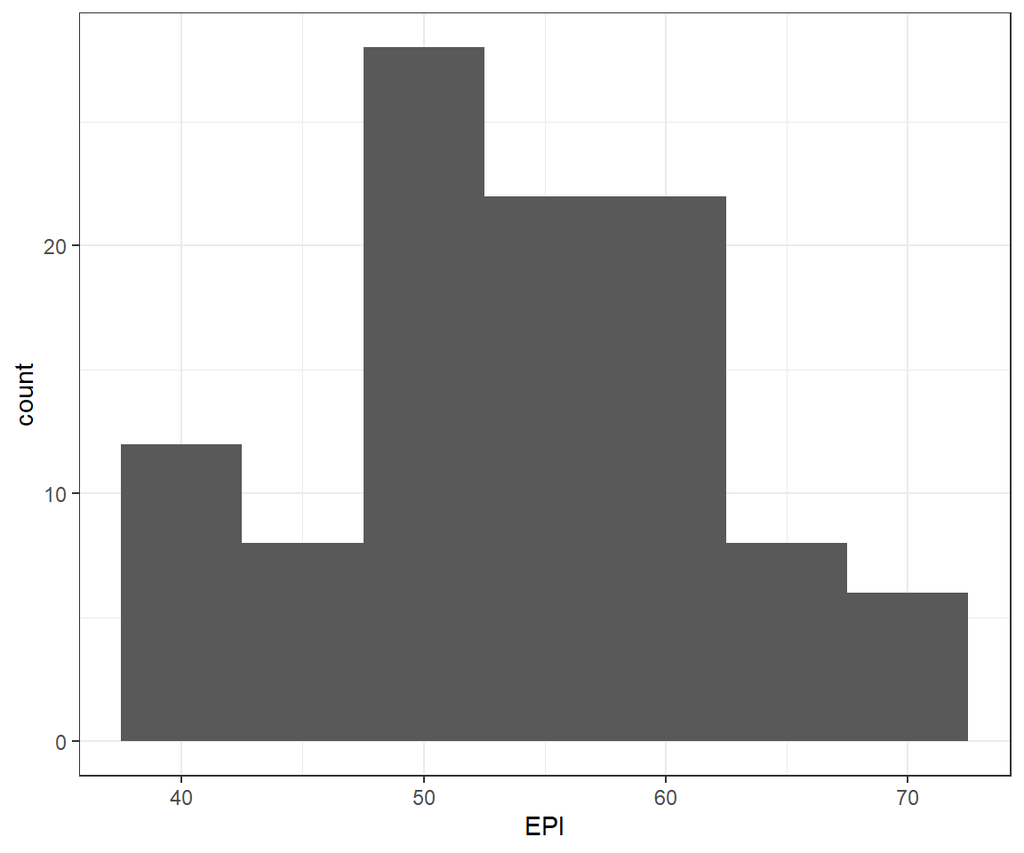

```r
responderam = paises$responderam_prop * 100

paises %>%
  ggplot(aes(x = EPI)) +
  geom_histogram(binwidth = 5)
```

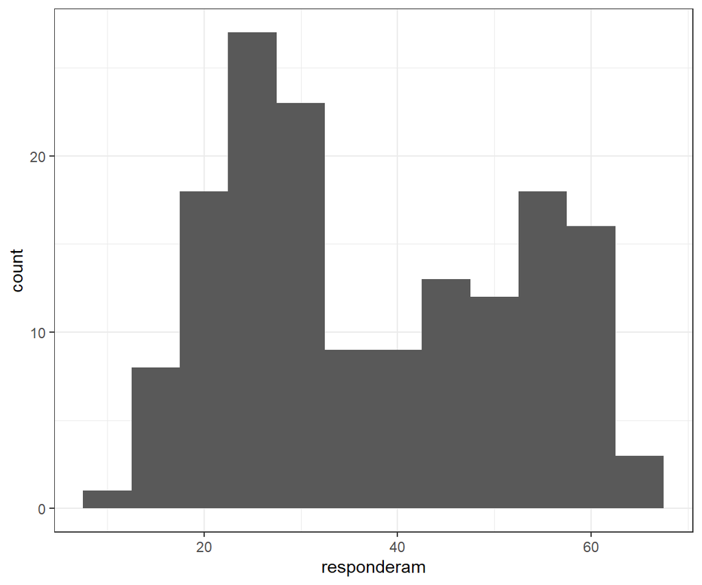

```r
paises %>%
  ggplot(aes(x = responderam)) +
  geom_histogram(binwidth = 5)
```

*Relação entre EPI e taxa de resposta:*

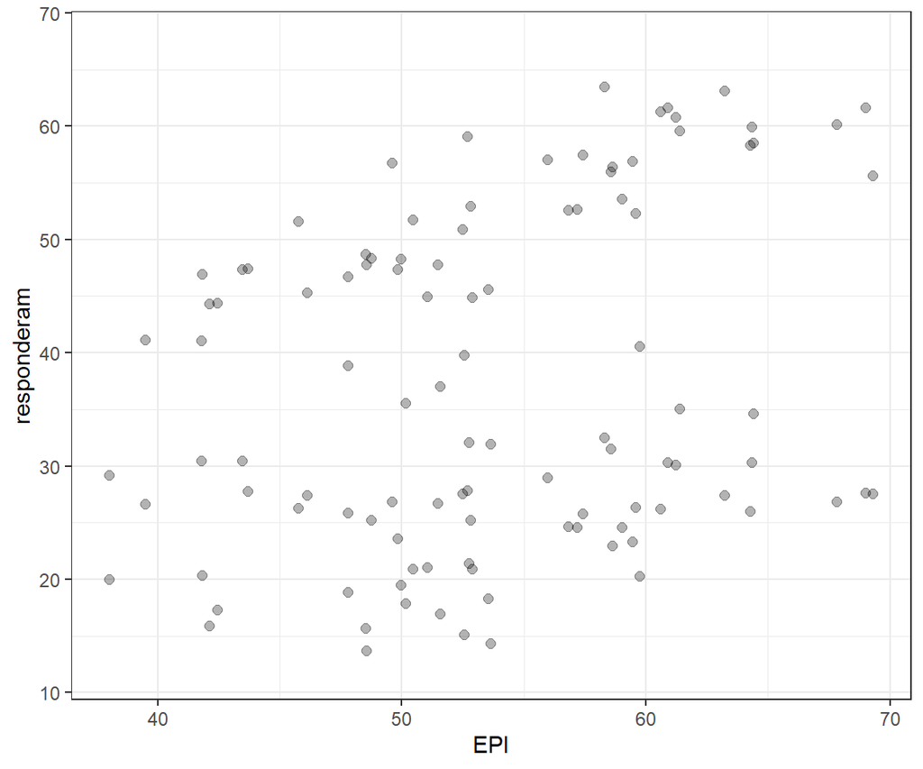

```r
paises %>%
  ggplot(aes(x = EPI, y = responderam))+
  geom_point(alpha = 0.3, size = 2)
```

*Relação entre EPI e taxa de resposta transformada:*

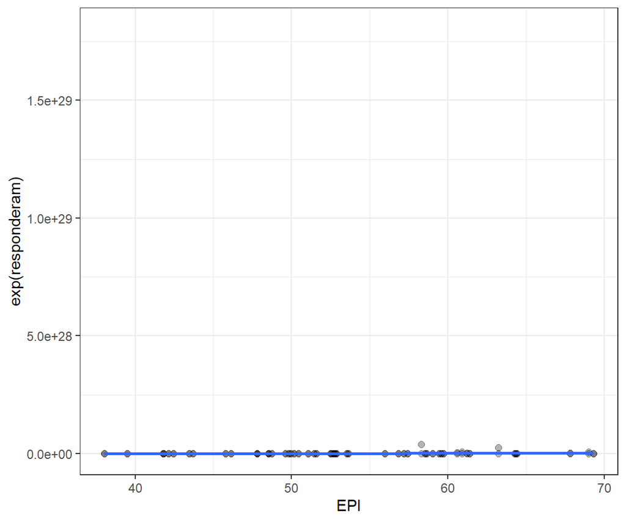

```r
paises %>%
  ggplot(aes(x = EPI, y = exp(responderam)))+
  geom_point(alpha = 0.3, size = 2)+
  geom_smooth(method = "lm", se = FALSE)
```

```r
# e^responderam = b0 + b1*EPI
# responderam = log(b0 + b1*EPI)

paises2 = paises %>%
    select(EPI, responderam_prop)%>%
    transform(responderam_prop = exp(responderam_prop))

model <- lm(responderam_prop ~ EPI,
           data = paises2)

# sintaxe broom / tidymodels:
tidy(model)
```

```
## # A tibble: 2 x 5
##   term        estimate std.error statistic  p.value
##   <chr>          <dbl>     <dbl>     <dbl>    <dbl>
## 1 (Intercept)  1.04      0.145        7.17 1.14e-10
## 2 EPI          0.00798   0.00268      2.98 3.62e- 3
```

```r
glance(model)
```

```
## # A tibble: 1 x 12
##   r.squared adj.r.squared sigma statistic p.value    df logLik   AIC   BIC
##       <dbl>         <dbl> <dbl>     <dbl>   <dbl> <dbl>  <dbl> <dbl> <dbl>
## 1    0.0785        0.0697 0.212      8.86 0.00362     1   15.3 -24.5 -16.5
## # ... with 3 more variables: deviance <dbl>, df.residual <int>, nobs <int>
```

*Inferência*

```r
model %>%
    tidy(conf.int = T, conf.level = .95) %>%
    select(-p.value)
```

```
## # A tibble: 2 x 6
##   term        estimate std.error statistic conf.low conf.high
##   <chr>          <dbl>     <dbl>     <dbl>    <dbl>     <dbl>
## 1 (Intercept)  1.04      0.145        7.17  0.752      1.33
## 2 EPI          0.00798   0.00268      2.98  0.00266    0.0133
```

**A Regressão linear simples foi utilizada para analisar a associação entre o EPI e a taxa de pessoas que responderam alguma pergunta no StackOverflow e SuperUser. Um modelo no formato responderam = log(1.03 + 0.007xEPI) explica apenas 7.8% da variância da variável de resposta (R^2 = 0,078). O aumento de 1% do EPI em um país produz um aumento de 0.0079 (IC 95% [0.002; 0.01]) no valor esperado da taxa de resposta. O efeito observado aparentemente é pouco relevante, visto que o valor de acréscimo é muito baixo.**

### Descrição da relação entre GNI (produto interno bruto per cápita) dos países e a taxa de pessoas daquele país que responderam alguma pergunta no StackOverflow:

*Distribuição do GNI e da taxa de resposta:*

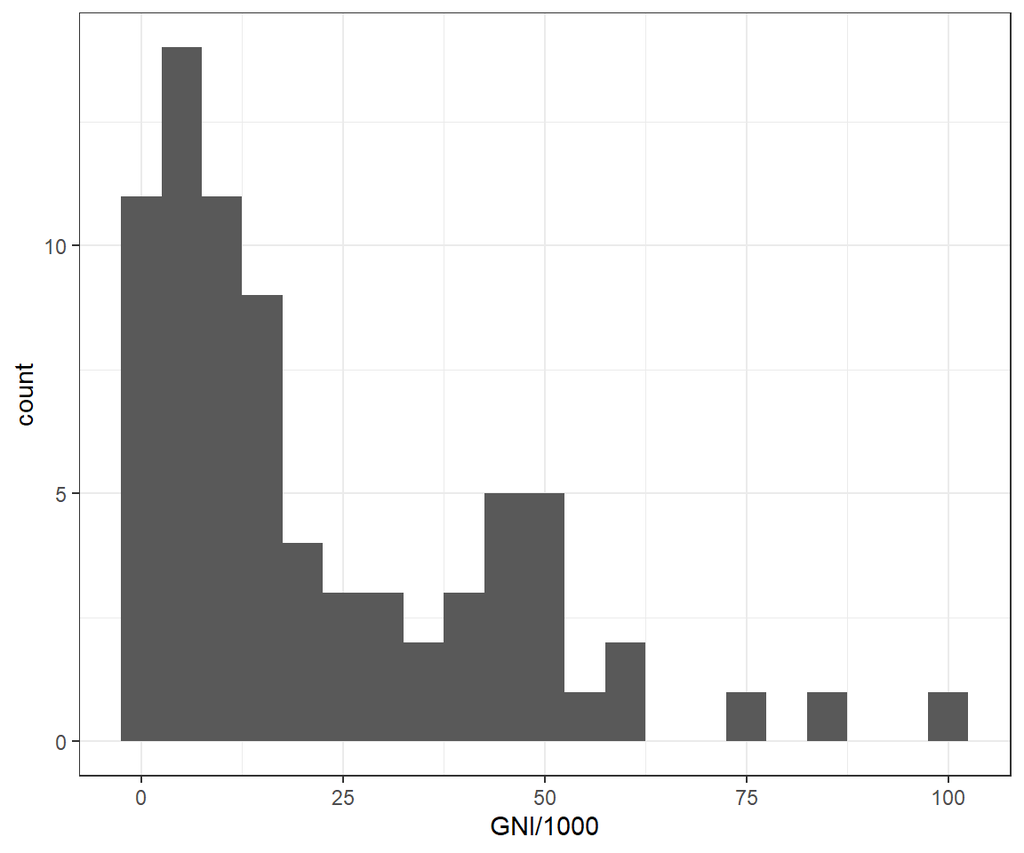

```r
paises2 = paises  %>%
    filter(site == "StackOverflow")

responderam = paises2$responderam_prop * 100

paises2 %>%
  ggplot(aes(x = GNI/1000)) +
  geom_histogram(binwidth = 5)
```

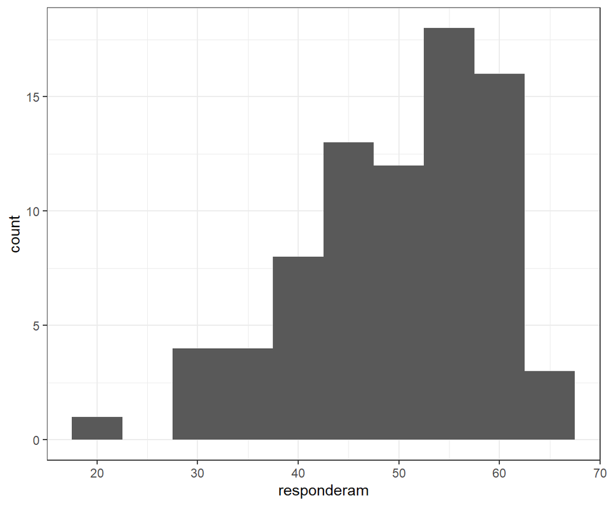

```r
paises2 %>%
  ggplot(aes(x = responderam)) +
  geom_histogram(binwidth = 5)
```

*Relação entre GNI e taxa de resposta:*

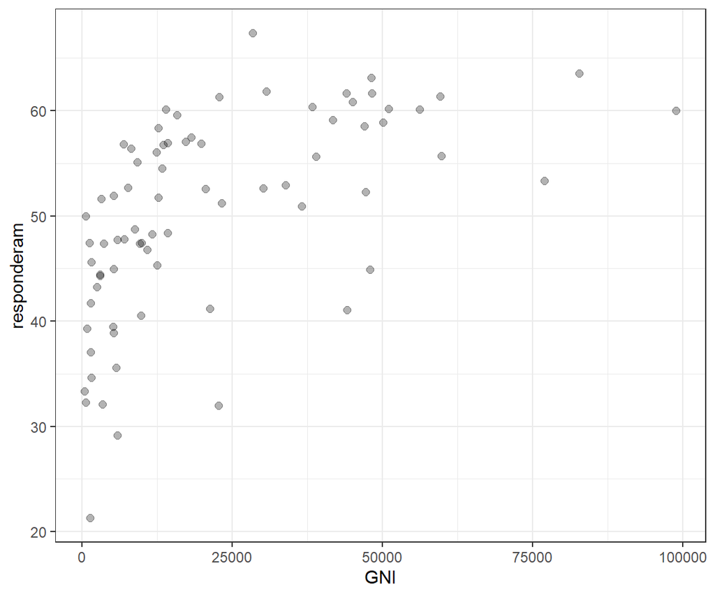

```r
paises2 %>%
  ggplot(aes(x = GNI, y = responderam))+
  geom_point(alpha = 0.3, size = 2)
```

*Relação entre GNI transformado e taxa de resposta:*

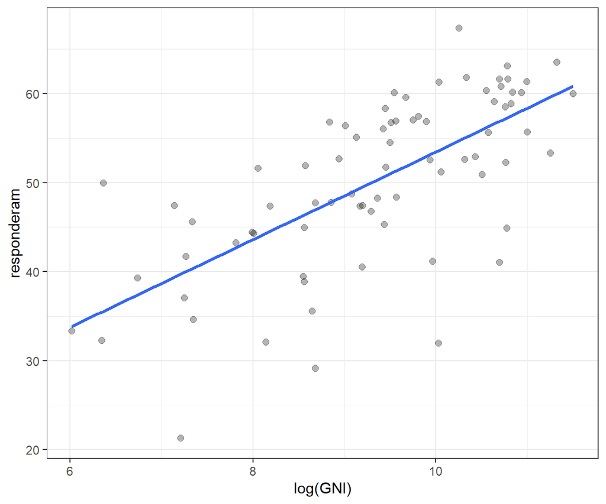

```r
paises2 %>%
  ggplot(aes(x = log(GNI), y = responderam))+
  geom_point(alpha = 0.3, size = 2) +
  geom_smooth(method = "lm", se = FALSE)
```

```r
# responderam = b0 + b1*log(GNI)

paises3 = paises2 %>%
    transform(GNI = log(GNI))

model2 <- lm(responderam_prop ~ GNI,
           data = paises3)

# sintaxe broom / tidymodels:
tidy(model2)
```

```
## # A tibble: 2 x 5
##   term        estimate std.error statistic  p.value
##   <chr>          <dbl>     <dbl>     <dbl>    <dbl>
## 1 (Intercept)   0.0422   0.0588      0.718 4.75e- 1
## 2 GNI           0.0492   0.00623     7.90  1.99e-11
```

```r
glance(model2)
```

```
## # A tibble: 1 x 12
##   r.squared adj.r.squared  sigma statistic  p.value    df logLik   AIC   BIC
##       <dbl>         <dbl>  <dbl>     <dbl>    <dbl> <dbl>  <dbl> <dbl> <dbl>
## 1     0.458         0.450 0.0712      62.4 1.99e-11     1   94.0 -182. -175.
## # ... with 3 more variables: deviance <dbl>, df.residual <int>, nobs <int>
```

*Inferência*

```r
model2 %>%
    tidy(conf.int = T, conf.level = .95) %>%
    select(-p.value)
```

```
## # A tibble: 2 x 6
##   term        estimate std.error statistic conf.low conf.high
##   <chr>          <dbl>     <dbl>     <dbl>    <dbl>     <dbl>
## 1 (Intercept)   0.0422   0.0588      0.718  -0.0749    0.159
## 2 GNI           0.0492   0.00623     7.90    0.0368    0.0616
```